# Final Project

Final Project Sumner MacArthur 2025-04-24

## Introduction

Media. We all know it, we all love it. Many of us are consumers of it. Most people consume this media through one of a few streaming services: Netflix, Hulu, Disney+, HBO, Paramount+, and others. There is, however, another way to consume media: piracy. Using extra-legal means, one may be able to download and play copyrighted material without paying the appropriate copywrite holders! Now, one interesting thing to take a look at, is how the pricing of streaming services influences the number of people who pirate content

### Brass Tacks

So here is where the rubber meets the road, the data analysis. First we need to read in the data:

```r
rdata1 <- read_csv("../Data/streaming_service.csv")
stream <- rdata1 |>
  # you have to use paste0 because default paste adds a space in between
  mutate(date=as.POSIXct(paste0("01-",date),format='%d-%b-%Y'))|>
  mutate(service = as.factor(service))

rdata2 <- read_csv("Responses_Final.csv")
pirate <- rdata2 |>
  mutate(date = day)

mdata <- stream |>
  full_join(pirate,by="date")|>
  select(-day)|>
  arrange(date)
```

> If you want to know how and where I got the piracy data, take a look at scrapr script

But before, we do anything else, let’s take a look at our data:

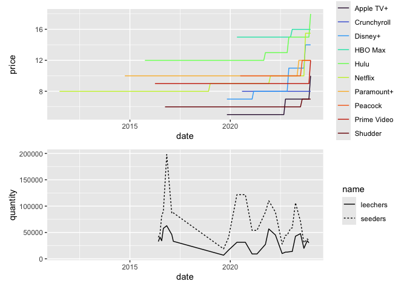

```r
# not sure why this doesn't work, but we can manually set it
trans = max(mdata$price)/max(max(mdata$seeders,na.rm=T),max(mdata$leechers,na.rm=T))

# useless now, because two y axies is kinda a pain to work with
# reguardless, very nice to take a look at the data
# mdata |>
#   ggplot(aes(x=date,color = service))+
#   geom_line(aes(y=price/trans))+
#   geom_line(aes(y=seeders,color="seeders"),colour = "black",
#             data=mdata[!is.na(mdata$seeders),])+
#   geom_line(aes(y=leechers,color="leechers"),colour = "black",
#             data=mdata[!is.na(mdata$leechers),])+
#   scale_y_continuous(
#     name = "# of Pirates",
#     # uh, the ~.* syntax is basically magic to me
#     sec.axis = sec_axis(transform=~.*trans, name = "Monthly Price of Streaming Services (in USD)")
#   )

stream <- mdata |>
  ggplot(aes(x=date,y=price,color=service))+
  geom_line()+
  coord_cartesian(xlim=c(min(mdata$date),max(mdata$date)))+
  scale_color_viridis_d(option="turbo")

pirate <- mdata |>
  pivot_longer(c("seeders","leechers"))|>
  filter(!is.na(value)) |>
  ggplot(aes(x=date,y=value,linetype=name))+
  geom_line()+
  coord_cartesian(xlim=c(min(mdata$date),max(mdata$date)))+
  ylab("quantity")

stream / pirate
```

### Data Analysis

Next, we will be using a general linear model in order to see if a simple correlation lies between pricing and piracy

```r
m.glm <- mdata |>
  mutate(pirates = seeders+leechers)|>
  select(-seeders,-leechers)|>
  glm(pirates~.^2,data=_)

summary(m.glm) |> pander()
```

|  | Estimate | Std. Error | t value | Pr(>\|t\|) |
| --- | --- | --- | --- | --- |
| **(Intercept)** | 400633 | 1708917 | 0.2344 | 0.8149 |
| **serviceCrunchyroll** | 597759 | 1328866 | 0.4498 | 0.6533 |
| **serviceDisney+** | 430610 | 1185035 | 0.3634 | 0.7167 |
| **serviceHBO Max** | 1113320 | 2944594 | 0.3781 | 0.7058 |
| **serviceHulu** | 603914 | 2062354 | 0.2928 | 0.77 |
| **serviceNetflix** | 335683 | 1075819 | 0.312 | 0.7554 |
| **serviceParamount+** | 479898 | 1575670 | 0.3046 | 0.761 |
| **servicePeacock** | 412333 | 1705934 | 0.2417 | 0.8093 |
| **servicePrime Video** | 519085 | 1399480 | 0.3709 | 0.7111 |
| **serviceShudder** | 579818 | 849105 | 0.6829 | 0.4955 |
| **date** | -0.0001504 | 0.001056 | -0.1424 | 0.8869 |
| **price** | -50921 | 284081 | -0.1792 | 0.8579 |
| **serviceCrunchyroll:date** | -0.0003484 | 0.0007861 | -0.4432 | 0.6581 |
| **serviceDisney+:date** | -0.0002969 | 0.000776 | -0.3826 | 0.7025 |
| **serviceHBO Max:date** | -0.001069 | 0.001796 | -0.5952 | 0.5524 |
| **serviceHulu:date** | -0.0004718 | 0.00124 | -0.3804 | 0.7041 |
| **serviceNetflix:date** | -0.0002137 | 0.0006701 | -0.3189 | 0.7502 |
| **serviceParamount+:date** | -0.0003158 | 0.0009565 | -0.3301 | 0.7417 |
| **servicePeacock:date** | -0.0001967 | 0.001056 | -0.1862 | 0.8525 |
| **servicePrime Video:date** | -0.0002959 | 0.0008209 | -0.3605 | 0.7189 |
| **serviceShudder:date** | -0.0003422 | 0.0005683 | -0.6021 | 0.5478 |
| **serviceDisney+:price** | 10066 | 22745 | 0.4426 | 0.6586 |
| **serviceHBO Max:price** | 49264 | 41089 | 1.199 | 0.232 |
| **serviceHulu:price** | 18615 | 23227 | 0.8014 | 0.4239 |
| **serviceNetflix:price** | 5836 | 22425 | 0.2602 | 0.795 |
| **serviceParamount+:price** | 8310 | 25088 | 0.3313 | 0.7408 |
| **servicePeacock:price** | -4047 | 27895 | -0.1451 | 0.8848 |
| **serviceShudder:price** | -2275 | 38311 | -0.05938 | 0.9527 |
| **date:price** | 2.446e-05 | 0.0001696 | 0.1442 | 0.8855 |

(Dispersion parameter for gaussian family taken to be 2219244310 )

| Null deviance: | 4.989e+11 on 220 degrees of freedom |
| --- | --- |
| Residual deviance: | 4.261e+11 on 192 degrees of freedom |

Now, many of these above rows can be ignored, the most important ones to pay attention to are price, and the interaction of price with the various services Here they are here:

```r
m.glm |>
  tidy() |>
  filter(grepl("price",term)) |>
  pander()
```

| term | estimate | std.error | statistic | p.value |
| --- | --- | --- | --- | --- |
| price | -50921 | 284081 | -0.1792 | 0.8579 |
| serviceCrunchyroll:price | NA | NA | NA | NA |
| serviceDisney+:price | 10066 | 22745 | 0.4426 | 0.6586 |
| serviceHBO Max:price | 49264 | 41089 | 1.199 | 0.232 |
| serviceHulu:price | 18615 | 23227 | 0.8014 | 0.4239 |
| serviceNetflix:price | 5836 | 22425 | 0.2602 | 0.795 |
| serviceParamount+:price | 8310 | 25088 | 0.3313 | 0.7408 |
| servicePeacock:price | -4047 | 27895 | -0.1451 | 0.8848 |
| servicePrime Video:price | NA | NA | NA | NA |
| serviceShudder:price | -2275 | 38311 | -0.05938 | 0.9527 |
| date:price | 2.446e-05 | 0.0001696 | 0.1442 | 0.8855 |

```r
# easystats::model_dashboard(m.glm)
```

Notably, the P-Values for all of these rows is rather high, implying that there is not a strong effect on piracy when prices change for streaming services.

This result, in and of itself could be an interesting and informative result, if the residuals are pretty even, a qqplot is largely linear, and the deviations largely follow a normal curve.

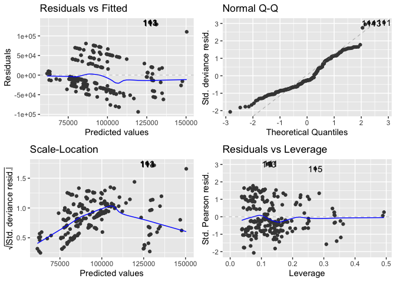

```r
autoplot(m.glm)
```

Unfortunately, as we can see from the above plots, none of those assertions hold true, so we cannot use a linear model to learn anything about our data.

This also lines up with the graphs seen at the very beginning of the analysis, where the incidence of seeders, leechers or anything else, really, didn’t seem to have much to do with the pricing of various streaming services.

## Conclusion

It remains to be seen if there is any link between piracy and pricing of streaming services. This is likely due to a linear Gaussian model not being the most effective for this sort of prediction. With that being said, we can at least make some more educated guesses about the correlation of this data than if we had not looked at all.

Due to the fact that the std. error is greater than the predicted estimate, and each estimate is not that far from zero, all things considered, there likely is not a correlation between streaming service pricing and piracy, or at least, not piracy as I have measured it here. Given how I have collected the data (only keeping track of the top 100 most popular torrents), there is a good chance that the rates of piracy are more influenced by very popular or influential movies coming out at a given time, as opposed to streaming service rates. Indeed, upon further inspection of the data, the highest day for both seeders and leechers occurred in November of 2016, and the top pirated item was the walking dead, season 7, and westworld, lending credence to this theory.

Subsequent investigations may have success using a different metric, or else, using more complex models that can account for issues in the data, such as they are.